# 7. Reporte simulaciones - Validación

Asistente de investigación: Valentina Andrade

última actualización: 27 December,2022

El presente informe tiene dos propósitos

1. Explorar el cambio entre los potenciales **postulantes PACE** entre las distintas simulaciones
2. Explorar la relación de la **probabilidad de postular** y el ranking del estudiante, en particular para **elegibles PACE**

# 1 Postulación PACE

| 10% | 15%-baseline | 15% | 20% | 25% | 30% | 35% | 40% |
| --- | --- | --- | --- | --- | --- | --- | --- |
| 3461 | 7616 | 7628 | 7783 | 8337 | 9242 | 10303 | 11458 |

En la **Figura 1, 2 y 3** exploramos la intersección de los elegibles PACE (todos los criterios se cumplen en el file de habilitados) y la masa de postulantes. Esto se muestra para *cada* simulación, manteniendo constante la masa de postulantes y sus postulaciones.

En la **Figura 1** obtenemos esta intersección sin desagregar, y en la **Figura 2 y 3** obtenemos la misma cifra pero *desagregando* la composición within simulación de las (a) personas que cumplen con el minimo puntaje matematicas y lenguaje (req_450) y (b) personas que aparecen marcadas como BEA.

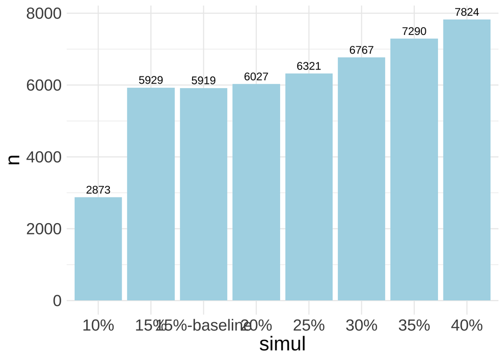

**Figura 1**. Intersección habilitados y postulantes en cada simulación

Como podemos ver en la **Figura 1** el aumento de la intersección es pequeña desde el 15% en adelante (a diferencia del kink del 10% al 15%). Al menos descriptivamente, eso podría ser evidencia sobre lo “*binding*” que es el requisito del ranking a la hora de postular (recordar el pop-up que aparece cuando los estudiantes postulan).

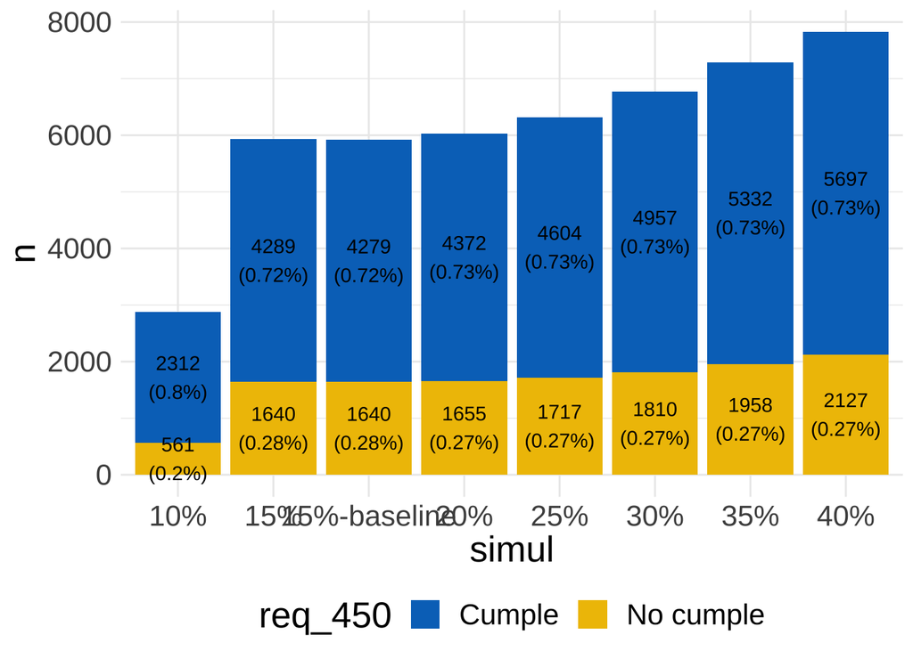

**Figura 2**. Intersección habilitados y postulantes en cada simulación, según si cumplen puntaje mínimo ponderado en maemáticas y lenguaje (450 puntos)

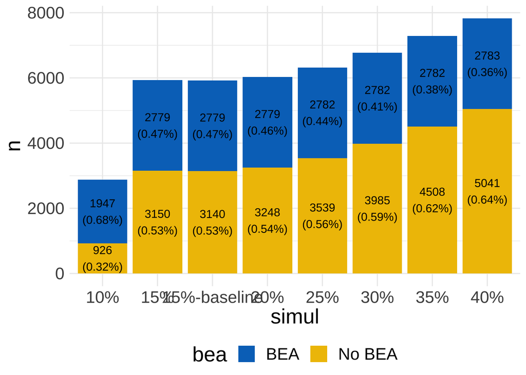

**Figura 3**. Intersección habilitados y postulantes en cada simulación, según si son elegibles BEA

**¿Qué encontramos?** No es que el porcentaje de personas que cumplen los requisitos en las simulaciones donde se relaja la condición de ranking sea mayor, más bien se mantiene constante desde el 20%.

Mientras que en la Figura 3 lo que se observa es que el porcentaje de BEA van disminuyendo proporcionalmente (pero menos entre 15 y 20). Esto nos dice que ese % de estudiantes que entra en cada simulación no se debe al requisito de puntajes. De hecho es solo notoria su diferencia cuando estamos bajo el 15%

# 2 Probabilidad de postular

Evidentemente de la **Figura 1** se desprende otro análisis necesario: el “kink” de postulantes que se produce en el 15%, y como este relativamente no cambia tanto luego de este 15%. Considerando solo a los estudiantes que tienen información de ranking y haber rendido las pruebas mínimas para postular, se analiza si la probabilidad de postular está afectada por el puntaje de ranking, con especial énfasis para estudiantes elegibles PACE.

En particular, pese a que la definición del 15% no sigue un proceso random de tal manera que se separe al grupo de control y tratamiento, el efecto en postular de estar sobre el 15% puede ser identificado si la asignación al grupo de tratamiento sigue un diseño de regresión discontinua (RDD). En este caso la *“running variable”* es el threshold del ranking (estar entre 0 y 0.15 de la distirbución) (en este caso sharp RDD).

## 2.1 Descriptivos

Primero mostraremos algunos descriptivos en la **Figura 4, 5 y 6**. En primera instancia podemos ver que un 58% de los elegibles para postular decide hacerlo. Al desagregar cifra se obtiene

1. Entre aquellos que no son elegibles PACE, el postular y no postular está bastante “balanceado”. Mientras que en los elegibles PACE un 78% de ellos deciden postular (**Figura 5**).
2. La Figura 6 es importante pues se hubiese esperado que los estudiantes elegibles PACE todos cumplieran con la condición del 15% (criterio_2). Explorando los datos hay 2.937 estudiantes elegibles PACE (todas las marcas == 1) pero que está bajo el threshold (por ejemplo mrun == 12045459 con 672 puntos y está en el 40% mejor de la clase). Esto es indicativo de que probablemente criterio_2 no se construye con la distribución del ptje de ranking.

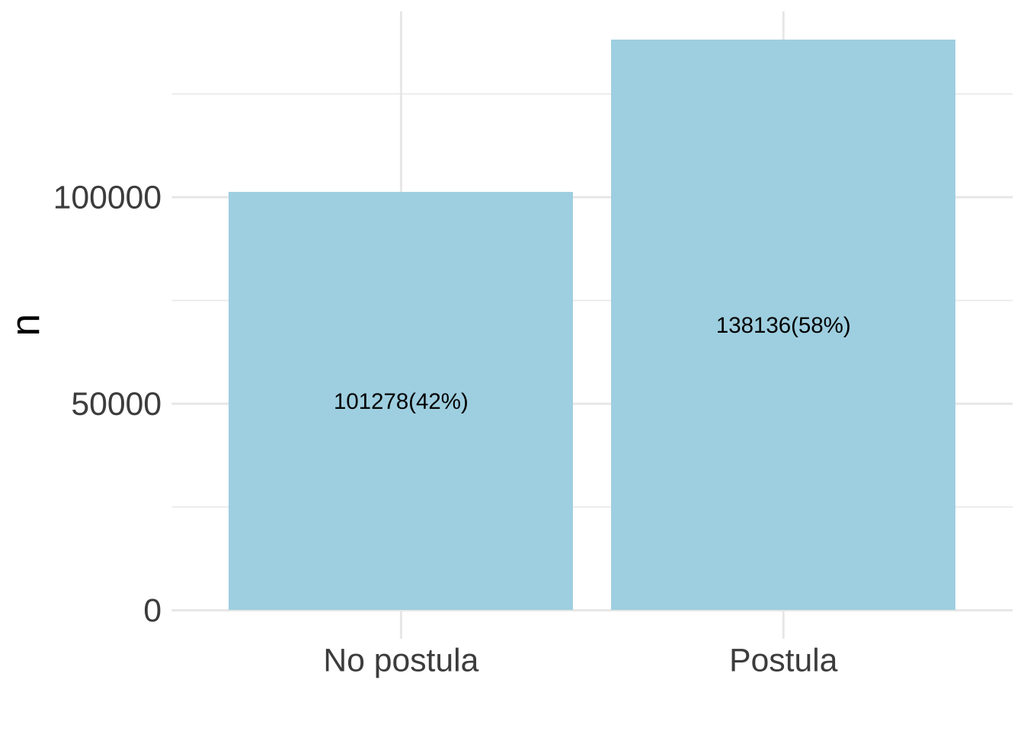

**Figura 4**. Distribución de postulación, de todos los habilitados para postular

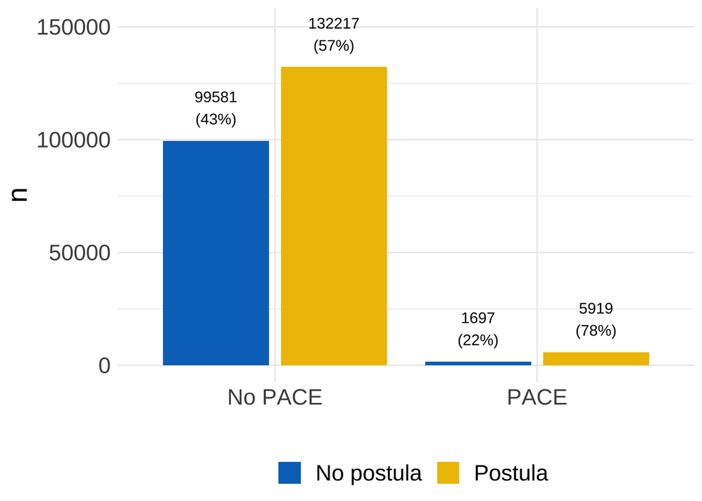

**Figura 5**. Distribución de postulación, de todos los habilitados para postular según habilitación PACE

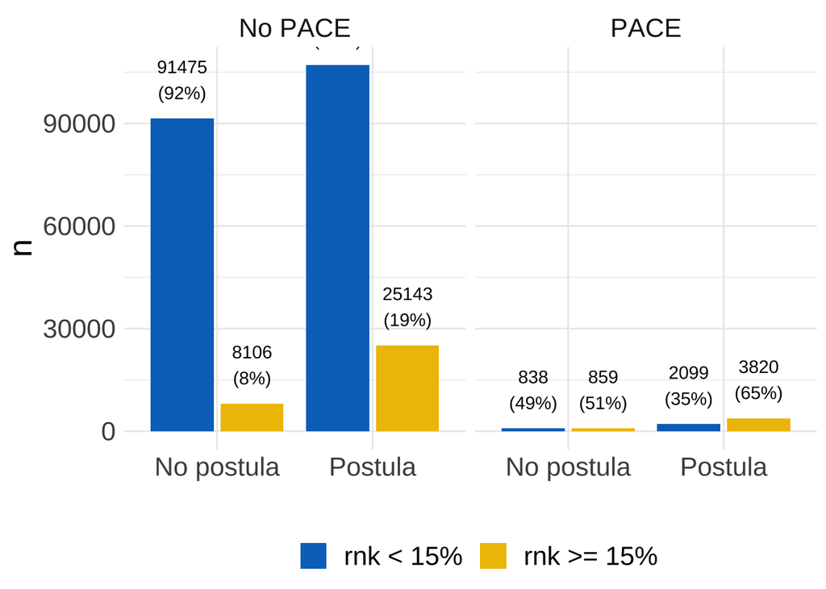

**Figura 6**. Distribución de postulación, de todos los habilitados para postular según habilitación PACE y si cumple con el cutpoint

## 2.2 Modelo general

|  | postula |  |  | postula |  |  |
| --- | --- | --- | --- | --- | --- | --- |
| Predictors | Odds Ratios | CI | p | Odds Ratios | CI | p |
| (Intercept) | 3.27 | 3.21 – 3.33 | **<0.001** | 3.17 | 3.11 – 3.23 | **<0.001** |
| rnk rbd | 0.18 | 0.17 – 0.18 | **<0.001** | 0.18 | 0.18 – 0.19 | **<0.001** |
| cumple pace [PACE] |  |  |  | 1.67 | 1.51 – 1.84 | **<0.001** |
| rnk rbd × cumple pace [PACE] |  |  |  | 0.28 | 0.16 – 0.48 | **<0.001** |
| Observations | 239414 |  |  | 239414 |  |  |
| R<sup>2</sup> Tjur | 0.057 |  |  | 0.057 |  |  |

**Recordemos que el el ranking sube estamos en una peor posición**. Dicho esto, por cada punto que empeora el ranking, los *odds* de postular disminuyen en 0.18. En promedio los PACE tienen mas chances de postular que los no PACE. La interacción nos dice que a medida que empeora el ranking, los PACE tienen menos chances de postular que los No pace

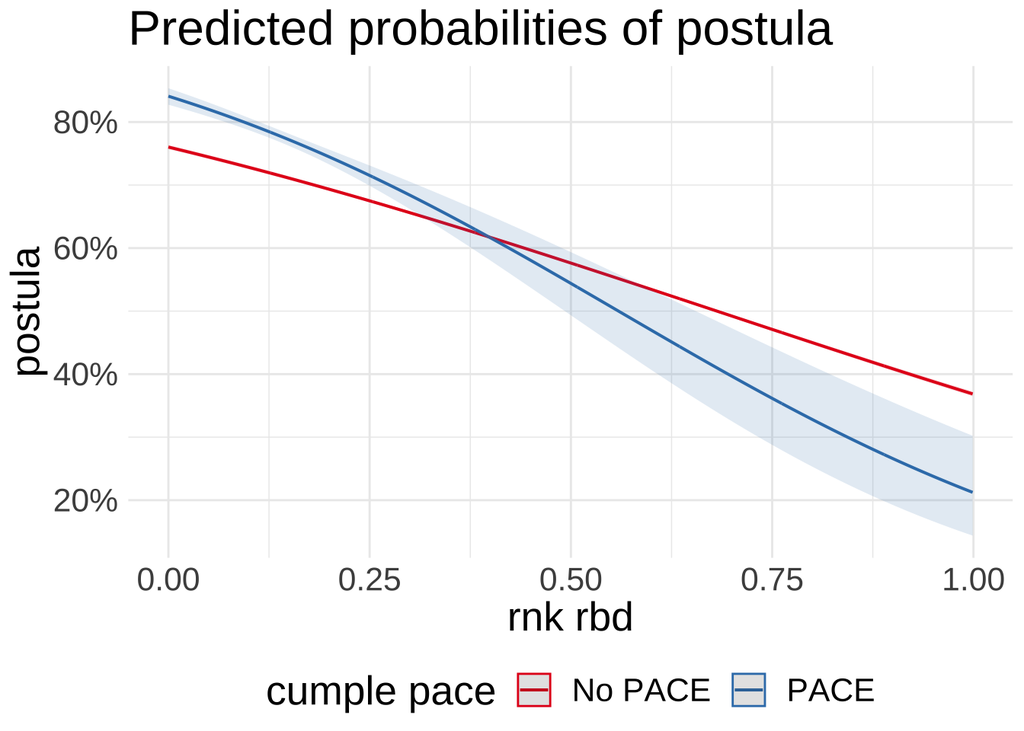

La Figura nos muestra que los que tiene menor ranking, tienen más probabilidad de postular. A su vez, las probabilidades predichas de postular en estudiantes PACE y no PACE tiene una pendiente distinta (los PACE son más sensibles a el efecto del ranking)

## 2.3 Regression Discontinuity

Postula (same slope)

Postula (separate slopes)

Predictors

Odds Ratios

CI

Odds Ratios

CI

(Intercept)

2.33 ***

2.28 – 2.37

2.33 ***

2.28 – 2.37

threshold [1]

1.23 ***

1.19 – 1.27

1.21 ***

1.15 – 1.27

rnk rbd - 0 15

0.20 ***

0.20 – 0.21

0.20 ***

0.20 – 0.21

threshold [1] × rnk rbd -  
0 15

0.84

0.49 – 1.44

Observations

239414

239414

R<sup>2</sup> Tjur

0.057

0.057

- p<0.05 ** p<0.01 *** p<0.001

En el coeficiente **threshold** podemos ver el efecto tratamiento. En promedio, la probabilidad de postular es mayor para individuos que estan dentro del 15% mejor de su generación, de aquellos que no.

Cuando se incorporan diferentes pendientes para cada modelo, la interpretacion del efecto tratamiento no se altera, solo levemente el coeficiente. En promedio, los *odds* de postular son 1.21 veces mayor de una persona que está en el 15% mejor de aquella que no.

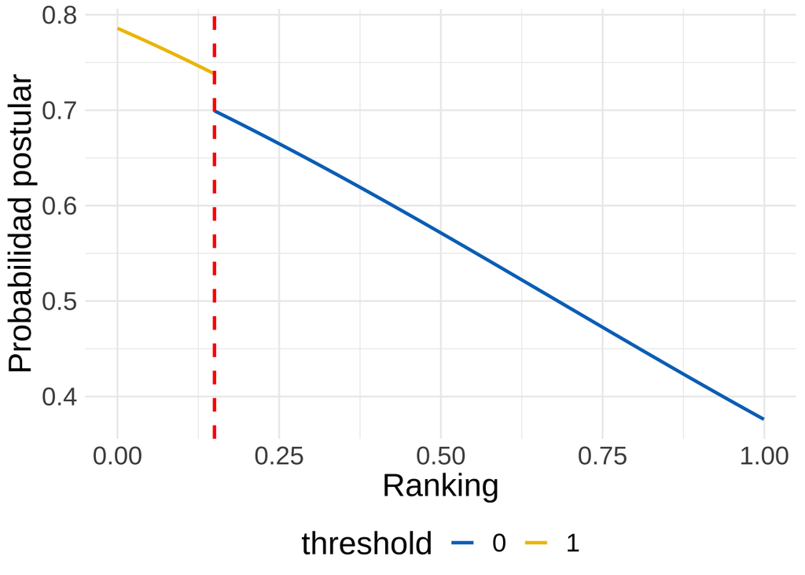

**Figura 7**. Estimación con diferentes pendientes

Como se puede ver en la figura 7, el proceso que describe la probabilidad de postular no es continuo entre quienes están en la mejor posición del ranking (threshold == 1), de aquellos que no.

Ahora bien nos gustaría profundizar este análisis para los estudiantes PACE, dado que nos interesa saber si el ranking condiciona mucho sus chances de postular.

Postula (todos)

Postula (PACE)

Predictors

Odds Ratios

CI

Odds Ratios

CI

Odds Ratios

CI

(Intercept)

2.33 ***

2.28 – 2.37

2.74 ***

2.43 – 3.09

2.30 ***

2.26 – 2.35

threshold [1]

1.21 ***

1.15 – 1.27

1.25 *

1.03 – 1.51

1.19 ***

1.13 – 1.25

rnk rbd - 0 15

0.20 ***

0.20 – 0.21

0.33

0.11 – 1.01

0.21 ***

0.20 – 0.22

threshold [1] × rnk rbd -  
0 15

0.84

0.49 – 1.44

0.09 *

0.01 – 0.73

0.98

0.56 – 1.73

Observations

239414

7616

231798

R<sup>2</sup> Tjur

0.057

0.017

0.053

- p<0.05 ** p<0.01 *** p<0.001

El resultado es similar cuando solo se hace análisis de submuestra. En promedio, los PACES que cumplen con el requisito de 15% tienen 1.25 mas chances de postular. Este efecto es levemente mayor en PACE que en no PACE, tal como se muestra en la siguiente Figura.

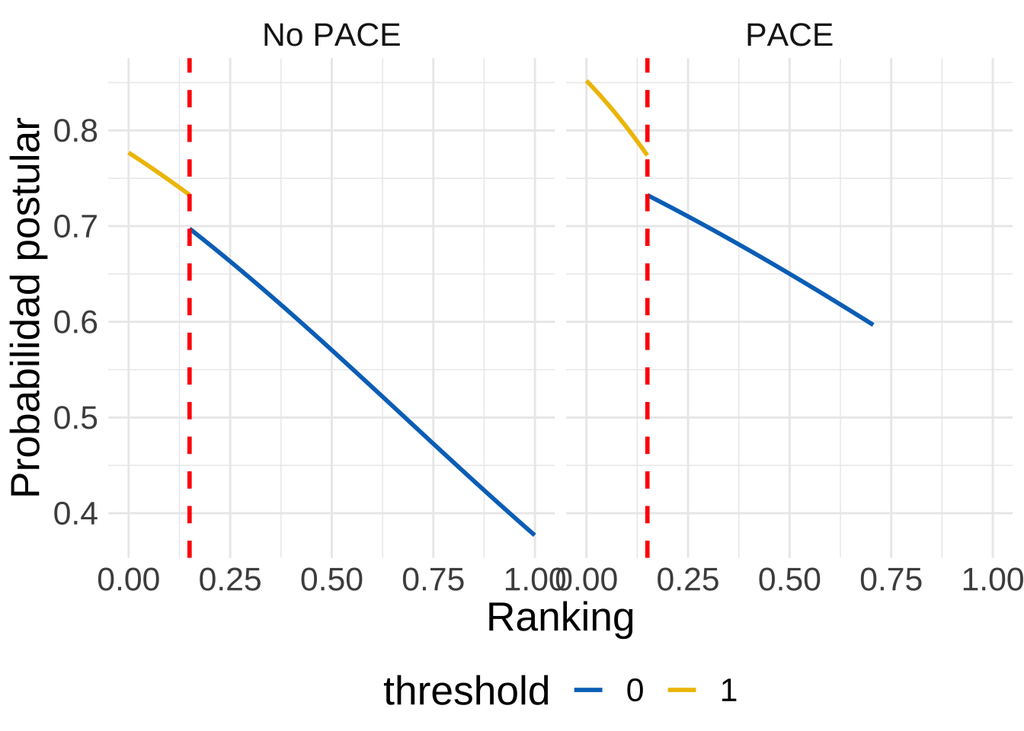

**Figura 8**. Estimación de la probabilidad de postular para PACE y no PACE

# 3 ¿Qué mide realmente el criterio de ranking de habilitación PACE?

Dado los resultados de la **Figura 6** surgió una duda que refiere a cómo es posible que existan elegibles PACE (cumplen todos los criterios) cuya posición en el ranking está sobre el 15% estipulado. En escrito rigor todos los elegibles PACE cumplir con el 15%, pero una vez que se calcula el ranking a partir de los puntajes de ranking se produce esta inconsistencia. Alrededor de 3.000 estudiantes aparecen con la marca `criterio_2 == 1` pero están en una posición mayor en el ranking que a un 15%. Recordemos lo que dice el criterio es (Artículo 2, REX 3395 - 2021)

> Encontrarse, ya sea, dentro del 15% superior de puntaje ranking de notas del establecimiento de egreso; o, haber obtenido un puntaje ranking igual o superior a 749 puntos a nivel nacional para el Proceso de Admisión 2022. A efectos de la segunda alternativa, en el referido puntaje ranking nacional, se considerarán los puntajes obtenidos por los estudiantes egresados de establecimientos educacionales municipales, de administración delegada, de servicios locales de educación y particulares subvencionados el año 2020. Entre ambas opciones deberá optarse por la alternativa más beneficiosa para cada estudiante. - El 15% superior de puntaje ranking de notas del establecimiento de egreso, se obtiene ordenando en forma decreciente a los estudiantes egresados de cada establecimiento de acuerdo a sus propios puntajes ranking, considerando para esto exclusivamente a aquellos estudiantes que cumplan el primer criterio de habilitación. - Teniendo presente que el año escolar 2021 se encuentra en curso a la fecha de dictacion de este acto administrativo, para efectos de esta segunda alternativa, se considerará el puntaje ranking del año escolar 2020.

Para abordar este problema se realizaron los siguientes ejercicios

1. Se volvió a calcular el puntaje de ranking considerando solo a la población que rindió el 2021 y excluyendo a los que no tienen información en puntaje de ranking (`ptje_ranking` == 0). Incluso con ello el número de estudiantes que incumplían aumentaba
2. Se hizo un análisis solo considerando a los habilitados PACE, y a ellos se le pegaron sus puntajes de ranking. Con ello se identificó por cada establecimiento `rbd` el puntaje de ranking en donde el `criterio_2` pasa de 1 a 0 (ordenando el puntaje de mayor a menor). Esto lo llamaré puntaje de ranking de corte

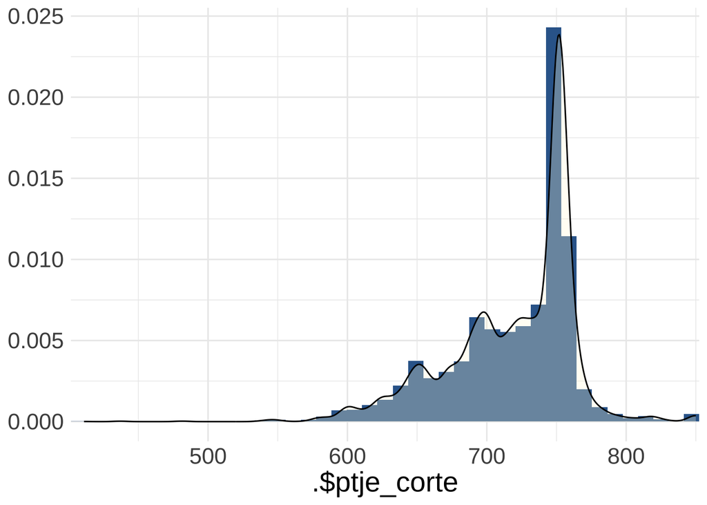

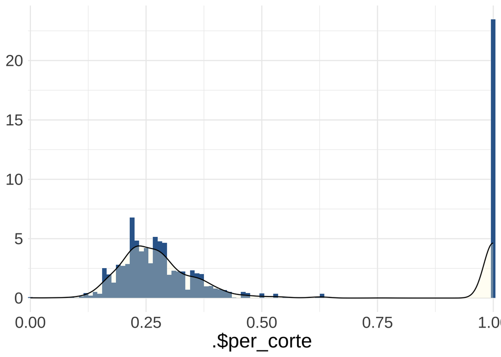

Es de notar que los % del puntaje de corte que están en 1 corresponden a 30 casos de estudiantes que deben adherirse a la segunda forma de cálculo (Ranking a nivel nacional). Ahora bien, no existe variable que nos pueda rectificar ello, por lo que es solo una hipótesis

3. En el tercer ejercicio solo se considera el mismo cáculo que en el punto 2, pero excluyendo a los que no cumplen el `criterio_1==1` (haber cursado 3 y 4 Medio en un establecimiento PACE, y haber egresado de 4 Medio el 2022). Los que no cumplen el criterio son 572 estudiantes (1.71%).

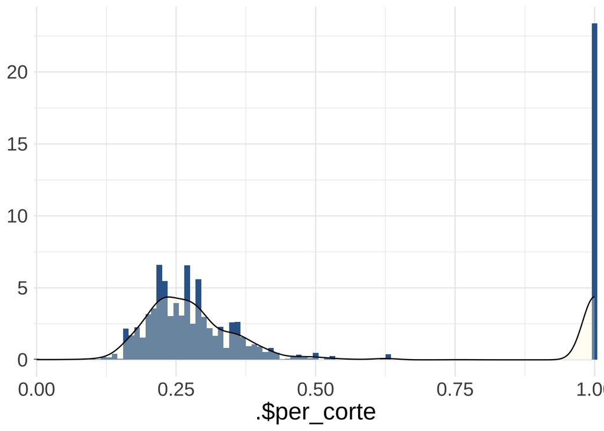

Como podemos ver, la distribución no cambia mucho. En promedio la distribución del corte está en el 44% mejor y con una desviación estándar de 31%.

Con ello, podemos concluir dos cosas

1. O la variable `ptje_ranking` no mide el ranking, o ´criterio_2´ no está marcando realmente a los que están en el 15% superior (por robustez se probó con criterio 1 y criterio 3, y los resultados daban más distorcionados. Además tienen el orden de los criterios puestos en las resoluciones administrativas)
2. Además de no poder obtener ranking para los PACE, tampoco estamos pudiendo replicar para regulares probablemente sin esta certeza.